# Chapter 8 - linear discriminant analysis (LDA): exercises

Author

Prof. Richard Wilkinson

## Question 1

Prove that the Bayes classifier can be written as given in Proposition 8.3.

**Solution**

The **Bayes classifier** assigns $\mathbf x$ to the population for which the posterior probability is highest:
$$d^{Bayes}(\mathbf x) =\arg \max_k {\mathbb{P}}(y=k \mid \mathbf x)$$

where
$${\mathbb{P}}(y=k \mid \mathbf x) = \frac{f_k(\mathbf x)\pi_k}{\sum_{j=1}^g f_k(\mathbf x)\pi_k}.$$

The denominator is the same for all $k$ and so we can simply maximize the numerator.

$$d^{Bayes}(\mathbf x) =\arg \max_k f_k(\mathbf x)\pi_k$$

The value of $x$ that maximizes some function $h(x)$ is the same as the value that maximises $w(h(x))$ if $w(\cdot)$ is a monotone increasing function. Thus we can maximize the logarithm:

$$d^{Bayes}(\mathbf x) =\arg \max_k \log f_k(\mathbf x)+\log\pi_k$$

In addition, maximizing $h(x)$ is the same as minimizing $-h(x)$, and so

$$d^{Bayes}(\mathbf x) =\arg \min_k -\log f_k(\mathbf x)-\log\pi_k$$

In the cases where the population $\Pi_k$ has a $N_p({\boldsymbol{\mu}}_k,\boldsymbol{\Sigma})$ distribution, then substituting in the MVN likelihood for $f_k$ we can see that
$$d^{Bayes}(\mathbf x)= \arg\min_{k} \frac{1}{2}(\mathbf x-{\boldsymbol{\mu}}_k)^\top \boldsymbol{\Sigma}^{-1} (\mathbf x-{\boldsymbol{\mu}}_k)- \log \pi_k.$$

Expanding the brackets we can see that
$$\begin{align*}
d^{Bayes}(\mathbf x)&= \arg\min_{k} \frac{1}{2}(\mathbf x-{\boldsymbol{\mu}}_k)^\top \boldsymbol{\Sigma}^{-1} (\mathbf x-{\boldsymbol{\mu}}_k)- \log \pi_k\\
&= \arg\min_k \frac{1}{2}( \mathbf x^\top \boldsymbol{\Sigma}^{-1} \mathbf x- 2{\boldsymbol{\mu}}_k^\top \boldsymbol{\Sigma}^{-1} \mathbf x+ {\boldsymbol{\mu}}_k^\top \boldsymbol{\Sigma}^{-1}{\boldsymbol{\mu}}_k) - \log \pi_k\\
&= \arg\min_k \frac{1}{2}( - 2{\boldsymbol{\mu}}_k^\top \boldsymbol{\Sigma}^{-1} \mathbf x+ {\boldsymbol{\mu}}_k^\top \boldsymbol{\Sigma}^{-1}{\boldsymbol{\mu}}_k) - \log \pi_k\\
&= \arg\max_k {\boldsymbol{\mu}}_k^\top \boldsymbol{\Sigma}^{-1} \mathbf x-\frac{1}{2} {\boldsymbol{\mu}}_k^\top \boldsymbol{\Sigma}^{-1}{\boldsymbol{\mu}}_k + \log \pi_k\\
\end{align*}$$
where the third line follows as $\mathbf x^\top \boldsymbol{\Sigma}^{-1} \mathbf x$ doesn’t depend upon $k$.

Thus we’ve shown that
$$d^{Bayes}(\mathbf x)= \arg\max_k \delta_k(\mathbf x)$$
where
$$\delta_k(\mathbf x) = {\boldsymbol{\mu}}_k^\top \boldsymbol{\Sigma}^{-1} \mathbf x-\frac{1}{2}{\boldsymbol{\mu}}_k^\top \boldsymbol{\Sigma}^{-1}{\boldsymbol{\mu}}_k + \log \pi_k$$
as required.

## Question 2

Prove that $\mathbf W^{-1}\mathbf B$ and $\mathbf W^{-\frac{1}{2}}\mathbf B\mathbf W^{-\frac{1}{2}}$ have the same eigenvalues and find an expression relating their eigenvectors.

**Solution**

Suppose $\lambda$ is an eigenvalue of $W^{-1/2}BW^{-1/2}$ with corresponding eigenvector $\mathbf v$. Let $\mathbf u= W^{-1/2}\mathbf v$. Then
$$\begin{align*}
W^{-1}B\mathbf u&= W^{-1/2}W^{-1/2} B W^{-1/2}\mathbf v\\
&= \lambda W^{-1/2} \mathbf v\\
&=\lambda \mathbf u.
\end{align*}$$
So $\lambda$ is also an eigenvalue of $W^{-1}B$.

## Question 3

Prove Proposition 8.1 that states the discriminant regions are convex. Note that region $\mathcal{R}$ is convex and connected if for $\mathbf x_1, \mathbf x_2 \in \mathcal{R}$ we have
$$\lambda \mathbf x_1+(1-\lambda) \mathbf x_2 \in \mathcal{R} \mbox{ for all } \lambda \in [0,1].$$

**Solution**

$\mathbf x$ classifies to $\mathcal{R}_i$ if $\delta_i(\mathbf x) > \delta_j(\mathbf x)$ for all $j \not = i$.

Suppose $\mathbf x_1, \mathbf x_2 \in \mathcal{R}_i$. Then $\mathcal{R}_i$ is convex if for all $\lambda \in [0,1]$ we have $\lambda \mathbf x_1+(1-\lambda) \mathbf x_2 \in \mathcal{R}_i$.

$$\begin{align*}
\delta_i(\lambda \mathbf x_1+(1-\lambda) \mathbf x_2 ) &= \mathbf v_i^\top (\lambda \mathbf x_1 + (1-\lambda)\mathbf x_2)+c_i\\
&= \lambda (\mathbf v_1^\top \mathbf x_1 +c_i)+(1-\lambda)(\mathbf v_1^\top \mathbf x_2+c_i)\\
&= \lambda \delta_i(\mathbf x_1)+(1-\lambda)\delta_i(\mathbf x_2)\\
&> \lambda \delta_j(\mathbf x_1)+(1-\lambda)\delta_j(\mathbf x_2) \mbox{ for all } j \not = i\\
&= \delta_j(\lambda \mathbf x_1+(1-\lambda) \mathbf x_2 )
\end{align*}$$

Thus $\lambda \mathbf x_1+(1-\lambda) \mathbf x_2 \in \mathcal{R}_i$ and we can conclude $\mathcal{R}_i$ is connected and convex.

## Question 4

Consider $g=3$ bivariate normal populations with the same covariance matrix, given by
$${\boldsymbol{\mu}}_1 = \begin{pmatrix} 0 \\ 0 \end{pmatrix}, \quad
{\boldsymbol{\mu}}_2 = \begin{pmatrix} 0 \\ 1 \end{pmatrix}, \quad
{\boldsymbol{\mu}}_3 = \begin{pmatrix} 1 \\ 0 \end{pmatrix}, \quad
\boldsymbol{\Sigma}= \begin{pmatrix} 5 & 2 \\ 2 & 1 \end{pmatrix}.$$
Determine the three maximum likelihood discriminant rules and, hence, sketch the ML discriminant regions. Determine the point at which the three boundary lines meet.

**Solution**

Classify to population $k$ if

$$\delta_k(x) = 2 \mu_k^\top \Sigma^{-1} x - \mu_k^\top \Sigma^{-1}\mu_k >\delta_j(x)$$

In this example, $|\boldsymbol{\Sigma}|=1$ so $\boldsymbol{\Sigma}^{-1} = \begin{pmatrix} 1 & -2 \\ -2 & 5 \end{pmatrix}$. If we substitute the values of ${\boldsymbol{\mu}}_k$ and let $\mathbf x=(x, \; y)^\top$ we find

$$\begin{align*}
\delta_1(\mathbf x) &= 0\\
\delta_2(\mathbf x) &= -4x+10y-5\\
\delta_3(\mathbf x) &= 2x-4y-1
\end{align*}$$

We can then find the boundary between each pair of decision regions.

- First, we consider $\Pi_1$ and $\Pi_2$. The boundary is at $\delta_1(\mathbf x)=\delta_2(\mathbf x)$ which is the line
  $$y = \frac{1}{2}+\frac{2}{5}x$$
  And by considering the origin ($\delta_1(0)=0, >\delta_2(0)=-5$) we can see we classify to $\Pi_1$ if
  $$y < \frac{1}{2}+\frac{2}{5}x.$$
- Next, we consider $\Pi_1$ and $\Pi_3$. The boundary is at $\delta_1(\mathbf x)=\delta_3(\mathbf x)$ which is the line
  $$y = -\frac{1}{4}+\frac{1}{2}x$$
  Again by considering the origin ($\delta_1(0)=0>\delta_3(0)=-1$) we can see we classify to $\Pi_1$ if
  $$y > -\frac{1}{4}+\frac{1}{2}x.$$
- Finally, we consider $\Pi_2$ and $\Pi_3$. The boundary is at $\delta_2(\mathbf x)=\delta_3(\mathbf x)$ which is the line
  $$y = \frac{2}{7}+\frac{3}{7}x$$
  Again by considering the origin ($\delta_2(0)=-5 <\delta_3(0)=-1$) we can see we classify to $\Pi_2$ if
  $$y > \frac{2}{7}+\frac{3}{7}x.$$

We can plot these three discriminant boundaries:

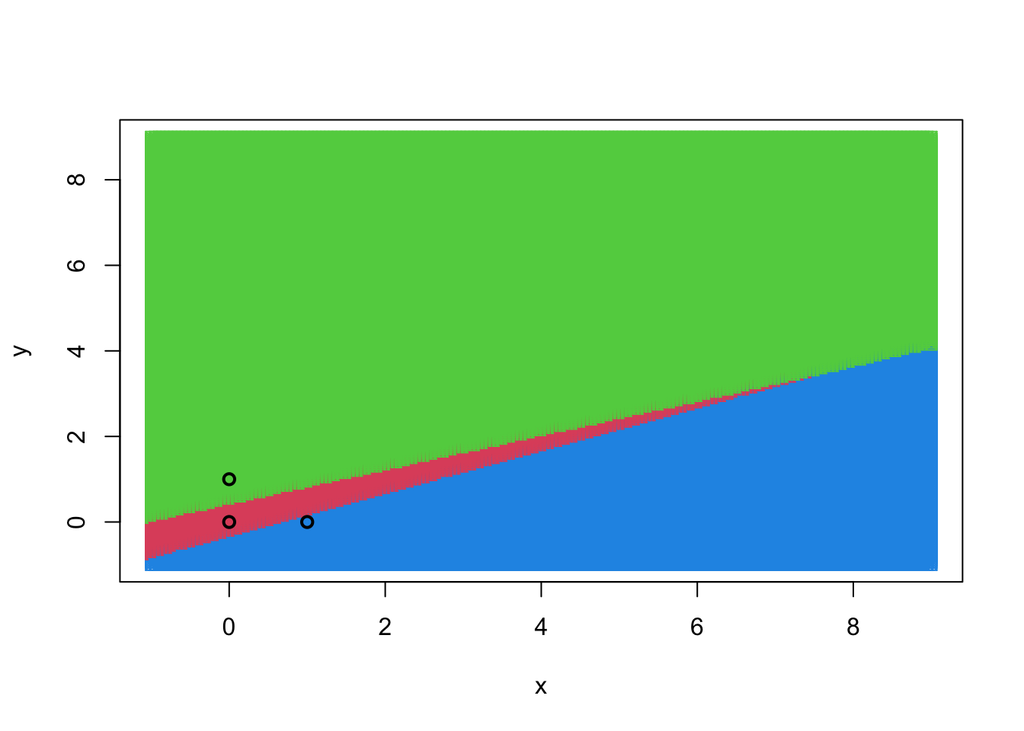

To find where the three boundary lines meet, take any two of the equations and solve them: For example, taking the boundary between regions 1 and 2, and between 1 and 3 gives the equations

$$\begin{align*}
-4x +10y &=5\\
2x-4y&=1
\end{align*}$$
which can be shown to have a solution at at $x=\frac{15}{2}$ and $y=\frac{7}{2}$.

## Question 5

The`palmerpenguins` R package contains size measurements of adult foraging penguins near Palmer Station, Antarctica. We will begin by looking at a subset of this data, looking at just the *Adelie* ($n_1=151$) and *Chinstrap* ($n_2=68$) penguins, and just the *bill length* and *bill depth* measurements. The sample mean and covariance for each group are

$$\begin{align*}
{\boldsymbol{\mu}}_{A}&=\begin{pmatrix}38.8 \\18.3 \\\end{pmatrix} \qquad \boldsymbol{\Sigma}_A = \begin{pmatrix}7.09&1.27 \\1.27&1.48 \\\end{pmatrix}\\
{\boldsymbol{\mu}}_{C}&=\begin{pmatrix}48.8 \\18.4 \\\end{pmatrix}\qquad \boldsymbol{\Sigma}_C = \begin{pmatrix}11.2&2.48 \\2.48&1.29 \\\end{pmatrix}
\end{align*}$$

1. Find the ML discriminant rule for allocating a new penguin $\mathbf x=(x_1,x_2)^T$ as either *Adelie* or *Chinstrap* assuming that the population covariance matrices for the two groups are equal. In particular, determine the sample ML rule for allocating the new observation $\mathbf z$. Find the equation of the straight line which separates the two allocation regions and plot the two regions graphically.

**Solution**

The pooled unbiased estimate of the common covariance matrix is given by
$$\mathbf S_u = \frac{1}{151+68-2}(151 \boldsymbol{\Sigma}_A + 68 \boldsymbol{\Sigma}_B) = \begin{pmatrix}8.43&1.66 \\1.66&1.43 \\\end{pmatrix}.$$

Further calculation shows that
$$\mathbf S_u^{-1} = \begin{pmatrix}0.154&-0.178 \\-0.178&0.903 \\\end{pmatrix}.$$

If we assume that the observations are samples from bivariate normal populations then the sample ML discriminant rule allocates a new observation $\mathbf x=(x_1,x_2)$ to $\Pi_A$ if $\hat{\mathbf a}^\top(\mathbf x-\hat{\mathbf h}) > 0$, where
$$\hat{\mathbf a} = \mathbf S_u^{-1}({\boldsymbol{\mu}}_A - {\boldsymbol{\mu}}_B) = \begin{pmatrix}-1.53 \\1.72 \\\end{pmatrix}$$
and
$$\hat{\mathbf h} = \frac{1}{2}({\boldsymbol{\mu}}_A + {\boldsymbol{\mu}}_C) = \begin{pmatrix}43.8 \\18.4 \\\end{pmatrix}.$$
So, we classify a new penguin $\mathbf x$ as Adelie if
$$\begin{eqnarray*}
\hat{\mathbf a}^\top (\mathbf x-\hat{\mathbf h}) &=& -1.53 x_1+1.72 x_2 + 35.4>0
\end{eqnarray*}$$

Therefore, the equation of the straight line which separates the two allocation regions is
$$x_2 =
0.89 x_1 -20.6.$$

The boundary is shown below. Above the line we allocate $\mathbf x$ to $\Pi_A$ and below the line we allocate $\mathbf x$ to $\Pi_C$.

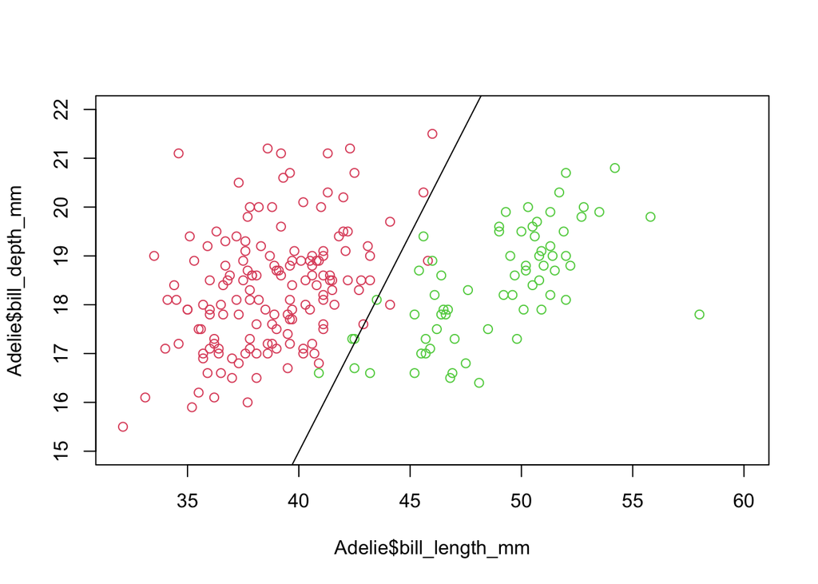

2. Find the Bayes discriminant rule estimating the prior probabilities using the observed frequencies $n_1$ and $n_2$. How does this differ to the ML rule?

**Solution**

The Bayes discriminant rule is to classify $\mathbf x$ to population A if
$$\hat{\mathbf a}^\top(\mathbf x-\hat{\mathbf h})> \log\frac{\hat{\pi}_C}{\hat{\pi}_A}.$$

We estimate $\hat{\pi}_A=\frac{151}{151+68}= 0.69$ and $\hat{\pi}_C= 0.31$. Thus, we classify a new penguin $\mathbf x$ as Adelie if
$$\begin{eqnarray*}
\hat{\mathbf a}^\top (\mathbf x-\hat{\mathbf h}) &=& -1.53 x_1+1.72 x_2 + 35.4> \log(0.31/0.69)=-0.8
\end{eqnarray*}$$

Therefore, the equation of the straight line which separates the two allocation regions is
$$x_2 =
0.89 x_1 -21.1.$$

The new Bayes boundary is shown below as a dashed line. We can see the effect of using the Bayes rule is that we move the decision boundary closer to the Chinstrap mean (the green points) as there are Adelie penguins in the training set and so the Bayes rule assumes that new penguins will continue to appear in proportion to the proportion seen in the training data.

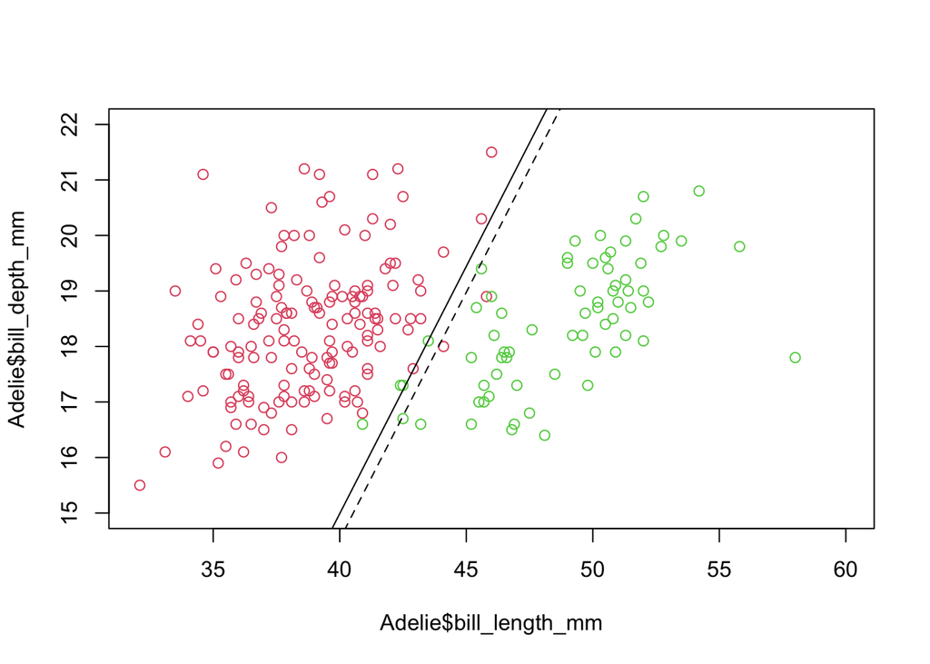

3. In addition to the *Adelie* and *Chinstrap* penguins, there are also $n_3=123$ measurements on *Gentoo* penguins with sample mean and covariance
   $${\boldsymbol{\mu}}_{G}=\begin{pmatrix}47.5 \\15 \\\end{pmatrix} \qquad \boldsymbol{\Sigma}_G = \begin{pmatrix}9.5&1.95 \\1.95&0.963 \\\end{pmatrix}$$
   The within-group covariance matrix is
   $$\frac{1}{342}(151 \mathbf S_A + 68 \mathbf S_C + 123 \mathbf S_G) = \begin{pmatrix}9.25&1.9 \\1.9&1.24 \\\end{pmatrix}.$$
   The eigendecomposition of $\mathbf W^{-1}\mathbf B$ is found in R to be

```
eigen() decomposition
$values
[1] 9.847607 1.269243

$vectors
           [,1]      [,2]
[1,]  0.3470103 0.3350582
[2,] -0.9378613 0.9421974
```

Calculate Fisher’s linear discriminant function using just a single LDA variable.

**Solution**

Fisher’s linear discriminant function projects the data onto the eigenvector corresponding to the largest eigenvalue of $\mathbf W^{-1}\mathbf B$.
$$\mathbf v=\begin{pmatrix}0.347 \\-0.938 \\\end{pmatrix}$$

Let $L(\mathbf x) = \mathbf v^\top\mathbf x$, then we allocate a new observation $\mathbf z$ to the group whose discriminant score $L({\boldsymbol{\mu}}_i)$ is closest to $L(\mathbf x)$. Now
$$\begin{align*}
L({\boldsymbol{\mu}}_A) = \mathbf v^\top {\boldsymbol{\mu}}_A = \begin{pmatrix}0.347&-0.938 \\\end{pmatrix}\begin{pmatrix}38.8 \\18.3 \\\end{pmatrix} = -3.75\\
L({\boldsymbol{\mu}}_C) = \mathbf v^\top {\boldsymbol{\mu}}_C = \begin{pmatrix}0.347&-0.938 \\\end{pmatrix}\begin{pmatrix}48.8 \\18.4 \\\end{pmatrix} = -0.33\\
L({\boldsymbol{\mu}}_G) = \mathbf v^\top {\boldsymbol{\mu}}_G = \begin{pmatrix}0.347&-0.938 \\\end{pmatrix}\begin{pmatrix}47.5 \\15 \\\end{pmatrix} = 2.43
\end{align*}$$

Therefore we allocate $\mathbf x$ to the Adelie population if
$$L(\mathbf x)<\frac{1}{2}(-3.75+-0.33) = -2.04$$

and to the Gentoo population if
$$L(\mathbf x)>\frac{1}{2}(-0.33+2.43) = 1.05$$
and otherwise to the Chinstrap population.

4. What would Fisher’s discriminant rule be if you use both LDA variables?

**Solution**

If we use both LDA variables we project the data points onto both eigenvectors. We also project the population means onto the eigenvectors. We classify new points according to which projected population mean they are closest to.

## Question 6

Try Q2 from the 2020-21 paper

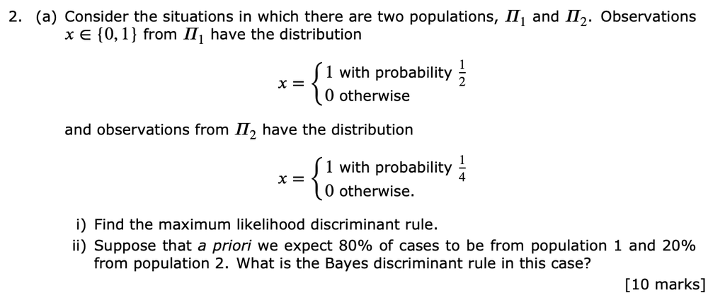

**Solution**

1. The likelihood of $x$ for population 1 is
   $$f_1(x) = \frac{1}{2}$$
   and for population 2 it is
   $$f_2(x) = 0.25^x0.75^{1-x}.$$

We can see that
$$f_1(0)<f_2(0) \mbox{ and } f_1(1) > f_2(1)$$
Thus the ML discriminant rule is
$$d(x) = \begin{cases} 1 \mbox{ if } x=1\\
2 \mbox{ if } x=0
\end{cases}$$

2. $$\begin{align*}
   {\mathbb{P}}(y=1 | x=0) &\propto f_1(0) \pi_1=0.5\times 0.8=0.4\\
   {\mathbb{P}}(y=2 | x=0) &\propto f_2(0) \pi_2= 0.75 \times 0.2 = 0.15
   \end{align*}$$
   and so $d(0) = 1$. Similarly
   $$\begin{align*}
   {\mathbb{P}}(y=1 | x=1) &\propto f_1(1) \pi_1=0.5\times 0.8=0.4\\
   {\mathbb{P}}(y=2 | x=1) &\propto f_2(1) \pi_2= 0.25 \times 0.2 = 0.05
   \end{align*}$$
   and so $d(1)=1$. Thus the Bayes discriminant rule is to always classify to population 1.